# SVM project

# 3 SVM assignment

## 3.1 complete an rmarkdown file on the stock you selected.

You will turn in the URL for your github accout that has the repo for this assignment.

### 3.1.1 Identify the stock you use for this assignment.

Why did you choose this particular stock?

I selected Tailored Brands because I wanted to see if the stock performed well or not. I had a friend that recommended purchasing this stock. I purchase and sold the stock in a short period of time. I think I may have sold too soon and am interested to see how the stock performed

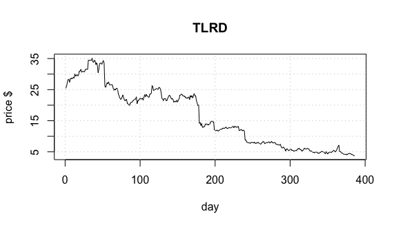

```r
knitr::include_graphics("TLRDplot.png")
```

### 3.1.2 Use this template to get the SVM:

1. Training and Test sets:

2. How well did the SVM do?

[figure not shown]

```r
knitr::include_graphics("pred2.png")
```

[figure not shown]

```r
knitr::include_graphics("pred3.png")
```

3. Tune the algorithm- i.e. find optimal gamma and cost values.

### 3.1.3 Evaluate SVM performance

1. Did you exmine using other than the ‘open’, ‘low’, ‘high’, ‘close’ prices and volume as predictors?

```r
table(pred4,YtrainSet2)
```

```
##      YtrainSet2
## pred4 D E U
##     D 9 0 0
##     E 0 7 0
##     U 0 0 0
```

3. Would you put your own $$ in this SVM?

No, I would not risk my own money in this SVM. Predictions are not accurate enough for me to put my own money on the line.